# Project: Investigate a Dataset - The Movie Database

### Challenges:

> **Pandas**: Categorizing a column by a range - had I been able to do so, I would have used it to produce a reasonable hist plot

```python
#Remove NaN values from the 'genre' column before applying split
movies_df = movies_df[movies_df['genres'].notnull()]
```

```python
#create a new column called new_genres with the genres split into separate genre names instead of strings
new_genres =movies_df.genres.map(lambda x: x.split('|')).apply(pd.Series).unstack()
movies_vote = movies_df.join(pd.DataFrame(new_genres.reset_index(level=0, drop=True)))
movies_vote.rename(columns={0: 'new_genres'}, inplace=True)
movies_vote.dropna(subset=['new_genres'], inplace=True)
movies_vote.head(10)
```

|  | genres | original_title | budget | revenue | director | runtime | vote_count | release_year | new_genres |
| --- | --- | --- | --- | --- | --- | --- | --- | --- | --- |
| 0 | Action\|Adventure\|Science Fiction\|Thriller | Jurassic World | 150000000 | 1513528810 | Colin Trevorrow | 124 | 5562 | 2015 | Action |
| 0 | Action\|Adventure\|Science Fiction\|Thriller | Jurassic World | 150000000 | 1513528810 | Colin Trevorrow | 124 | 5562 | 2015 | Adventure |
| 0 | Action\|Adventure\|Science Fiction\|Thriller | Jurassic World | 150000000 | 1513528810 | Colin Trevorrow | 124 | 5562 | 2015 | Science Fiction |
| 0 | Action\|Adventure\|Science Fiction\|Thriller | Jurassic World | 150000000 | 1513528810 | Colin Trevorrow | 124 | 5562 | 2015 | Thriller |
| 1 | Action\|Adventure\|Science Fiction\|Thriller | Mad Max: Fury Road | 150000000 | 378436354 | George Miller | 120 | 6185 | 2015 | Action |
| 1 | Action\|Adventure\|Science Fiction\|Thriller | Mad Max: Fury Road | 150000000 | 378436354 | George Miller | 120 | 6185 | 2015 | Adventure |
| 1 | Action\|Adventure\|Science Fiction\|Thriller | Mad Max: Fury Road | 150000000 | 378436354 | George Miller | 120 | 6185 | 2015 | Science Fiction |
| 1 | Action\|Adventure\|Science Fiction\|Thriller | Mad Max: Fury Road | 150000000 | 378436354 | George Miller | 120 | 6185 | 2015 | Thriller |
| 2 | Adventure\|Science Fiction\|Thriller | Insurgent | 110000000 | 295238201 | Robert Schwentke | 119 | 2480 | 2015 | Adventure |
| 2 | Adventure\|Science Fiction\|Thriller | Insurgent | 110000000 | 295238201 | Robert Schwentke | 119 | 2480 | 2015 | Science Fiction |

```python
#Check if the most expensive movie has the highest vote_count and revenue
count_df = movies_vote.groupby("vote_count").sum().sort_values(["revenue", "budget"], ascending=False).head(1000)
count_df.head()
```

| vote_count | budget | revenue | runtime | release_year |
| --- | --- | --- | --- | --- |
| 8458 | 948000000 | 11126023388 | 648 | 8036 |
| 5292 | 800000000 | 8272712900 | 544 | 8060 |
| 201 | 645400000 | 6694510989 | 3307 | 57883 |
| 1277 | 1600000000 | 6234200409 | 889 | 18079 |
| 5562 | 600000000 | 6054115240 | 496 | 8060 |

```python
#Assess the summary statistics of the df grouped by 'vote_count'
count_df.describe()
```

|  | budget | revenue | runtime | release_year |
| --- | --- | --- | --- | --- |
| count | 1.000000e+03 | 1.000000e+03 | 1000.000000 | 1.000000e+03 |
| mean | 4.482257e+08 | 1.235502e+09 | 2655.405000 | 5.169165e+04 |
| std | 3.321538e+08 | 9.345579e+08 | 8679.248825 | 1.752142e+05 |
| min | 6.500000e+05 | 3.166360e+08 | 100.000000 | 1.988000e+03 |
| 25% | 2.040000e+08 | 6.184260e+08 | 396.000000 | 6.039000e+03 |
| 50% | 3.710000e+08 | 9.716641e+08 | 616.500000 | 1.006500e+04 |
| 75% | 6.000000e+08 | 1.552432e+09 | 1451.500000 | 2.611625e+04 |
| max | 2.862138e+09 | 1.112602e+10 | 112606.000000 | 2.237528e+06 |

```python
#Find which genre has the highest vote_count in the first top 1000 movies taken as a sample from the database
group = movies_vote.groupby(["new_genres","vote_count", "budget"]).sum()
total_count = group["revenue"].groupby(level=1, group_keys=False).head(1000)
total_count = total_count.nlargest()
total_count
```

```
new_genres       vote_count  budget
Action           8458        237000000    2781505847
Adventure        8458        237000000    2781505847
Fantasy          8458        237000000    2781505847
Science Fiction  8458        237000000    2781505847
Action           5292        200000000    2068178225
Name: revenue, dtype: int64
```

```
Text(0,0.5,'Revenue in Billion USD')
```

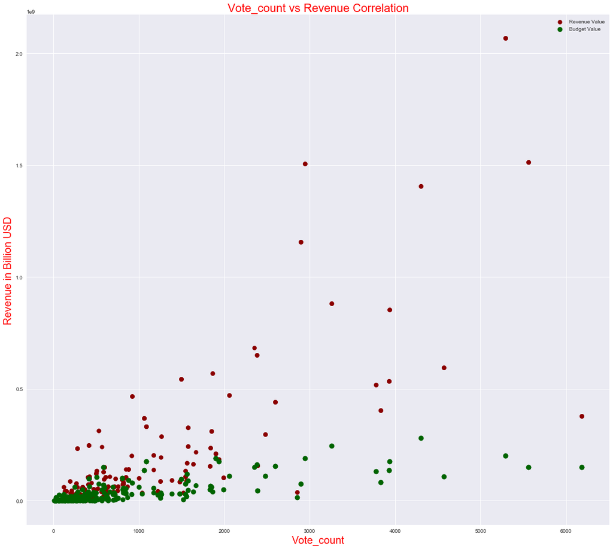

```python
#Create a Scatter plot to illustrate the relationship/correlation
ax = movies_vote.plot(kind='scatter', x='vote_count', y='revenue', color = 'DarkRed', label='Revenue Value', linewidth = 4)
movies_vote.plot(kind='scatter', x='vote_count', y='budget',
            color='DarkGreen', label='Budget Value', ax=ax, linewidth = 5);
plt.title('Vote_count vs Revenue Correlation', color = 'red', size=22)
plt.xlabel('Vote_count', color = 'red', size=20)
plt.ylabel('Revenue in Billion USD',color = 'red', size=20)
```

## QUESTION 3 - Which top genres brought in the highest revenue?

### Answer:

> The horizontal bar plot below clearly shows that Drama has the highest total number of occurrences in the given dataset. Is this enough to conclude that it also brings in the highest revenue? That is illustrated using Seaborn's swarmplot.

> The result calls for a future work on finding out how if the popularity of genres has evolved over the years as the societal makeup, values and the role of technology has seen a significant change.

### Challenges:

> **Pandas**: categorizing the data by release_year to analyze how some features have behaved between 1977 and 2015.

```python
#Get the summary statistics of the two categories to be explored
new_df.popularity.describe(), new_df.genres.describe()
```

```
(count    10865.000000
 mean         0.646446
 std          1.000231
 min          0.000065
 25%          0.207575
 50%          0.383831
 75%          0.713857
 max         32.985763
 Name: popularity, dtype: float64, count     10842
 unique     2039
 top       Drama
 freq        712
 Name: genres, dtype: object)
```

```python
#Select columns from the original data and create a new dataframe that will be used to answer the question asked
movies_df = df_movies[[ 'genres', 'original_title','budget', 'revenue', 'director', 'runtime', 'vote_count', 'release_year']]
movies_df.head()
#Remove NaN values from the 'genre' column before applying split
movies_df = movies_df[movies_df['genres'].notnull()]
```

```python
#create a new column called new_genres with the genres split into separate ones
new_genres = movies_df.genres.map(lambda x: x.split('|')).apply(pd.Series).unstack()
movies_df2 = movies_df.join(pd.DataFrame(new_genres.reset_index(level=0, drop=True)))
movies_df2.rename(columns={0: 'new_genres'}, inplace=True)
movies_df2.dropna(subset=['new_genres'], inplace=True)
movies_df2.head(10)
```

|  | genres | original_title | budget | revenue | director | runtime | vote_count | release_year | new_genres |
| --- | --- | --- | --- | --- | --- | --- | --- | --- | --- |
| 0 | Action\|Adventure\|Science Fiction\|Thriller | Jurassic World | 150000000 | 1513528810 | Colin Trevorrow | 124 | 5562 | 2015 | Action |
| 0 | Action\|Adventure\|Science Fiction\|Thriller | Jurassic World | 150000000 | 1513528810 | Colin Trevorrow | 124 | 5562 | 2015 | Adventure |
| 0 | Action\|Adventure\|Science Fiction\|Thriller | Jurassic World | 150000000 | 1513528810 | Colin Trevorrow | 124 | 5562 | 2015 | Science Fiction |
| 0 | Action\|Adventure\|Science Fiction\|Thriller | Jurassic World | 150000000 | 1513528810 | Colin Trevorrow | 124 | 5562 | 2015 | Thriller |
| 1 | Action\|Adventure\|Science Fiction\|Thriller | Mad Max: Fury Road | 150000000 | 378436354 | George Miller | 120 | 6185 | 2015 | Action |
| 1 | Action\|Adventure\|Science Fiction\|Thriller | Mad Max: Fury Road | 150000000 | 378436354 | George Miller | 120 | 6185 | 2015 | Adventure |
| 1 | Action\|Adventure\|Science Fiction\|Thriller | Mad Max: Fury Road | 150000000 | 378436354 | George Miller | 120 | 6185 | 2015 | Science Fiction |
| 1 | Action\|Adventure\|Science Fiction\|Thriller | Mad Max: Fury Road | 150000000 | 378436354 | George Miller | 120 | 6185 | 2015 | Thriller |
| 2 | Adventure\|Science Fiction\|Thriller | Insurgent | 110000000 | 295238201 | Robert Schwentke | 119 | 2480 | 2015 | Adventure |
| 2 | Adventure\|Science Fiction\|Thriller | Insurgent | 110000000 | 295238201 | Robert Schwentke | 119 | 2480 | 2015 | Science Fiction |

```
Text(0.5,1,'Genres and their total count')
```

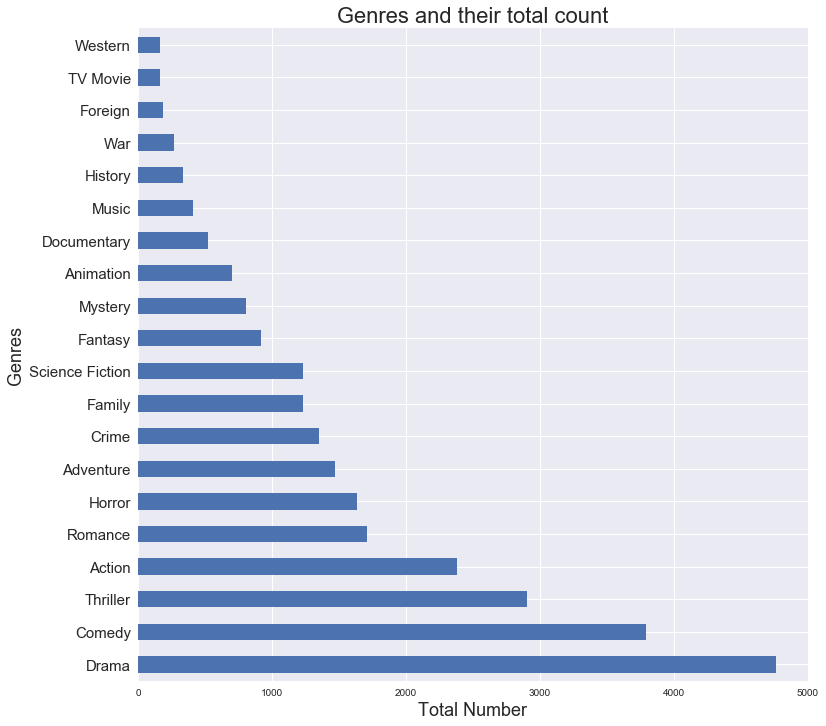

```python
#count and aggregate occurrences of each genre
t = movies_df2.groupby(by='new_genres').original_title.count().sort_values(ascending=False)
#find out which genre has the highest count
t.plot(kind='barh', figsize = (12,12))
plt.yticks(size = 15)
plt.ylabel('Genres', size = 18)
plt.xlabel('Total Number', size = 18)
plt.title('Genres and their total count', size = 22)
```

```python
#group = movies_df2.groupby(["new_genres","vote_count", "budget"]).sum()
group = movies_df2.groupby(["new_genres","vote_count", "budget"]).sum()
#group = df_movies.groupby(["director", "genres"]).sum()
total_count = group["revenue"].groupby(level=1, group_keys=False).head(10)
total_count = total_count.nlargest()
total_count
```

```
new_genres       vote_count  budget
Action           8458        237000000    2781505847
Adventure        8458        237000000    2781505847
Fantasy          8458        237000000    2781505847
Science Fiction  8458        237000000    2781505847
Action           5292        200000000    2068178225
Name: revenue, dtype: int64
```

```python
#sort non zero values in the budget column for convenience
expensive_df2 = movies_df2[(movies_df2['budget']>=0) & (movies_df2['revenue']>0)]
expensive_df2 = expensive_df2.sort_values(['revenue', 'budget'],ascending=[False, False])
expensive_df2 = expensive_df2.groupby(by = 'new_genres').original_title.count().sort_values(ascending=False)
expensive_df2.head()
```

```
new_genres
Drama       2274
Comedy      1771
Thriller    1423
Action      1260
Romance      877
Name: original_title, dtype: int64
```

```
Text(0.5,1,'Summary of Distribution of Revenue per Genres')
```

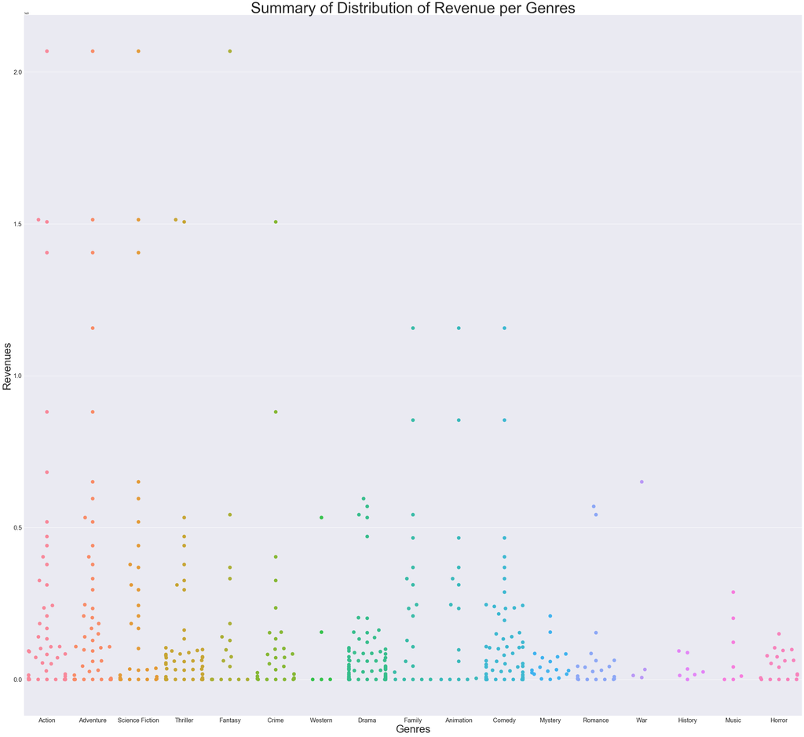

```python
#Which of the genres has the highest revenue
movies_df2 = movies_df2
#sns.violinplot(x="new_genres", y="revenue", data=movies_df2, inner = None)
sns.swarmplot(x="new_genres", y="revenue", data=movies_df2, size = 12, edgecolor = 'gray');
plt.subplots_adjust(top=1.9, right=1.9);
plt.yticks(size = 20)
plt.xticks(size = 20)
plt.ylabel('Revenues', size = 35)
plt.xlabel('Genres', size = 35)
plt.title('Summary of Distribution of Revenue per Genres', size = 50)
```

[figure not shown]

```python
#Which of the genres has the highest revenue
expensive_df2.plot(x = ['new_genres'], y = ['revenue'], kind = 'bar', color = ['blue'], figsize = (18, 9))

plt.suptitle('Revenue comparison per Genre', color = 'r', fontsize=16)
plt.xlabel('Genres')
plt.ylabel('Revenue');
```

## Summary Plot

> The pairplot(combination of stacked bar plot and scatter plot) below is a summary of how each genre behaves towards the three numerical features of the dataset clearly explored in this project.

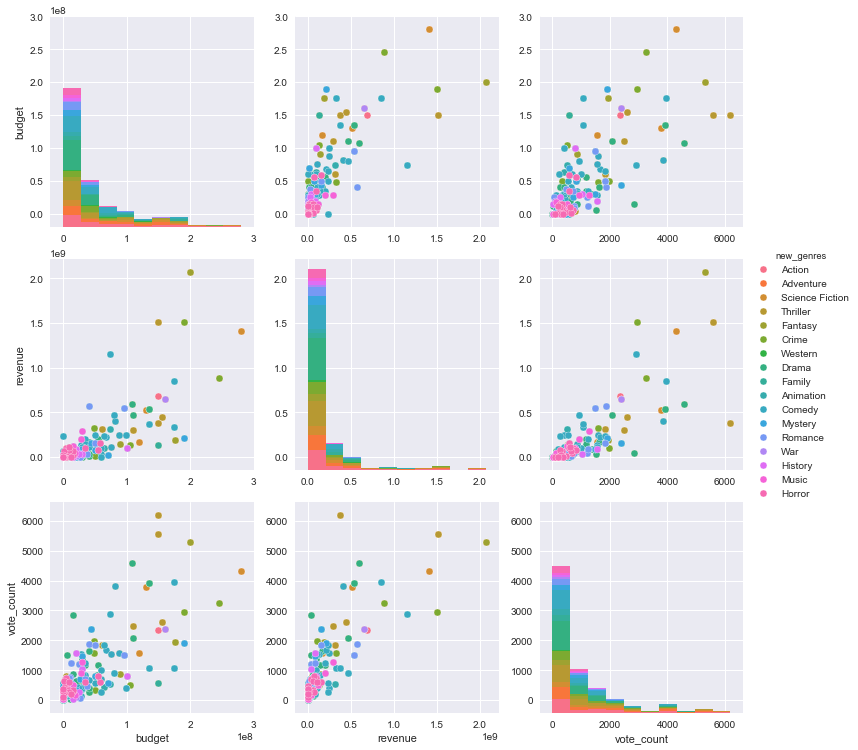

```python
#show how the genres relate with popularity, budget and revenue
genre_based = movies_df2[['original_title', 'budget', 'revenue', 'new_genres', 'vote_count']]
sns.pairplot(genre_based, hue='new_genres', size=3.5);
```